# final

# comparison pros between google and amazon

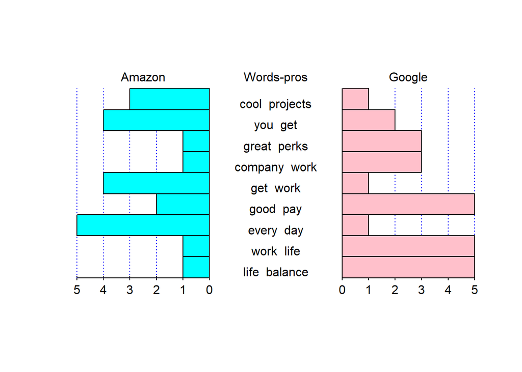

```r
common <- inner_join(x=googlebigrams,y=amazonbigrams,by="word")

common <- common %>%
  mutate(diff=abs(n.x-n.y)) %>%
  arrange(desc(diff)) %>%
  top_n(7) %>%
  select(n.y,n.x,word)
data <- data.frame(common$n.y,common$n.x,common$word)

pyramid(data,Llab = "Amazon",Rlab = "Google",Clab = "Words-pros",Cgap = 1)
```

## we find that people working in Google has better work life balance, and people in Amazon would have higher chance of geeting cool projects.

# Cons

## clean the data-cons

```r
amazon1$cons <- amazon1$cons %>%
  tm::removeWords(., words = stopwords("en")) %>%
str_replace_all(., "\n", " ") %>%
  str_replace_all(., "\\[\\w+\\s*[0-9]*]", "") %>%
  str_squish(.) %>%
  gsub("\\.","",.) %>%
  gsub("\\,","",.) %>%
  tolower()
```

## frequency-cons

```r
amazonconpr <- tm::MC_tokenizer(amazon1$cons)

amazoncontokenCount = as.data.frame(summary(as.factor(amazonconpr), maxsum = 1000))
    amazoncontotal = length(amazonconpr)
    amazoncontokenCount = data.frame(count = amazoncontokenCount[[1]],
                            word = row.names(amazoncontokenCount),
                            amazoncontotal = amazoncontotal,
                            row.names = NULL)
amazoncontokenCount <- amazoncontokenCount %>%
  arrange(desc(count)) %>%
  mutate(per=count/amazoncontotal) %>%
  top_n(10)
```

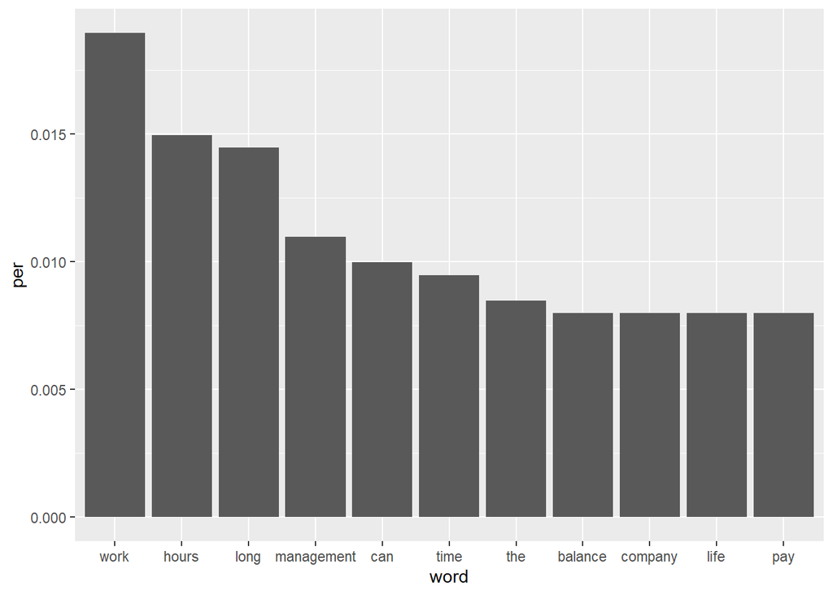

```r
amazoncontokenCount$word <- factor(amazoncontokenCount$word,levels = amazoncontokenCount$word[order(desc(amazoncontokenCount$per))])
ggplot(amazoncontokenCount,aes(word,per)) +
  geom_col()
```

## two words-cons

```r
amazonbigrams = amazon1 %>%
  unnest_tokens(., ngrams, cons, token = "ngrams", n = 2) %>%
  tidyr::separate(ngrams, c("word1", "word2"), sep = "\\s") %>%
  count(word1, word2, sort = TRUE)

amazonbigrams$word <- paste(amazonbigrams$word1, "", amazonbigrams$word2)
amazonbigrams <- amazonbigrams %>%
  select(c(word,n))

rmarkdown::paged_table(amazonbigrams)
```

| word | n |
| --- | --- |
| long hours | 20 |
| life balance | 13 |
| work life | 13 |
| hours can | 3 |
| next level | 3 |
| recruiting team | 3 |
| seems like | 3 |
| worklife balance | 3 |
| you may | 3 |
| 401k matching | 2 |

[output cut: 1791 more lines]

## bad work-life balance and long hours of working

## clean the data-cons

```r
google1$cons <- google1$cons %>%
  tm::removeWords(., words = stopwords("en")) %>%
str_replace_all(., "\n", " ") %>%
  str_replace_all(., "\\[\\w+\\s*[0-9]*]", "") %>%
  str_squish(.) %>%
  gsub("([a-z])([A-Z])", "\\1 \\2", .) %>%
  gsub("\\.","",.) %>%
  gsub("\\,","",.) %>%
  tolower()
```

## frequency-cons

```r
googleconpr <- tm::MC_tokenizer(google1$cons)

googlecontokenCount = as.data.frame(summary(as.factor(googleconpr), maxsum = 1000))
    googlecontotal = length(googleconpr)
    googlecontokenCount = data.frame(count = googlecontokenCount[[1]],
                            word = row.names(googlecontokenCount),
                            googlecontotal = googlecontotal,
                            row.names = NULL)
googlecontokenCount <- googlecontokenCount %>%
  arrange(desc(count)) %>%
  mutate(per=count/googlecontotal) %>%
  top_n(10)
```

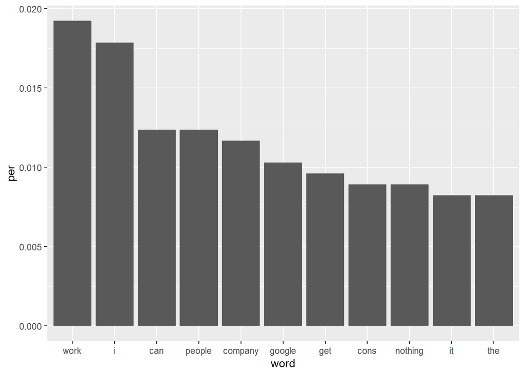

```r
googlecontokenCount$word <- factor(googlecontokenCount$word,levels = googlecontokenCount$word[order(desc(googlecontokenCount$per))])
ggplot(googlecontokenCount,aes(word,per)) +
  geom_col()
```

## two words-cons

```r
googlebigrams = google1 %>%
  unnest_tokens(., ngrams, cons, token = "ngrams", n = 2) %>%
  tidyr::separate(ngrams, c("word1", "word2"), sep = "\\s") %>%
  count(word1, word2, sort = TRUE)

googlebigrams$word <- paste(googlebigrams$word1, "", googlebigrams$word2)
googlebigrams <- googlebigrams %>%
  select(c(word,n))

rmarkdown::paged_table(googlebigrams)
```

| word | n |
| --- | --- |
| big company | 5 |
| get promoted | 5 |
| i think | 5 |
| no cons | 5 |
| hard get | 4 |
| can think | 3 |
| i can | 3 |
| long hours | 3 |
| too big | 3 |
| 2 hours | 2 |

[output cut: 1269 more lines]

## We can find the bad things employees think about Google is that it is a big company and difficult to be promoted. It is amazing that no cons appears among the top ones.

# comparison cons between google and amazon

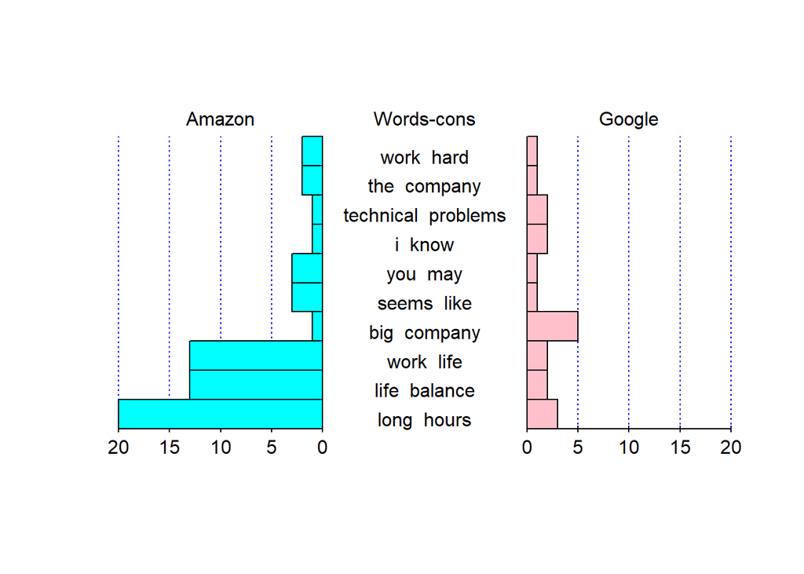

```r
common <- inner_join(x=googlebigrams,y=amazonbigrams,by="word")

common <- common %>%
  mutate(diff=abs(n.x-n.y)) %>%
  arrange(desc(diff)) %>%
  top_n(7) %>%
  select(n.y,n.x,word)
data <- data.frame(common$n.y,common$n.x,common$word)

pyramid(data,Llab = "Amazon",Rlab = "Google",Clab = "Words-cons",Cgap = 1)
```

## we find that Google has better work-life balance according to the current employee reviews.

# In conclution, we say that Amazon is more suitable for employees who view an intense workload as an opportunity, and Google is for people who cares more about work-life balance.

# find whether the sentiment score of the review has correlation with rating

## get the sentiment score amazon

```r
amazon1$word <- paste(amazon1$pros,"",amazon1$cons)
amazon1$index <- 1:nrow(amazon1)

tokens = amazon1 %>%
  unnest_tokens(word,word)
token <- tokens %>%
  inner_join(get_sentiments("afinn")) %>%
  group_by(index) %>%
  summarise(score=mean(value))
result <- token %>%
  inner_join(amazon1,by="index") %>%
  select(score,rating)

result <- result %>%
  mutate(rating= as.double(rating))

m <- lm(rating~score,data = result)
summary(m)
```

```
##
## Call:
## lm(formula = rating ~ score, data = result)
##
## Residuals:
##     Min      1Q  Median      3Q     Max
## -3.0184 -0.7224  0.1621  0.8554  1.6805
##
## Coefficients:
##             Estimate Std. Error t value Pr(>|t|)
## (Intercept)  3.55248    0.15583  22.796   <2e-16 ***
## score        0.23298    0.09504   2.451   0.0161 *
## ---
## Signif. codes:  0 '***' 0.001 '**' 0.01 '*' 0.05 '.' 0.1 ' ' 1
##
## Residual standard error: 0.9928 on 92 degrees of freedom
## Multiple R-squared:  0.06131,    Adjusted R-squared:  0.05111
## F-statistic: 6.009 on 1 and 92 DF,  p-value: 0.01612
```

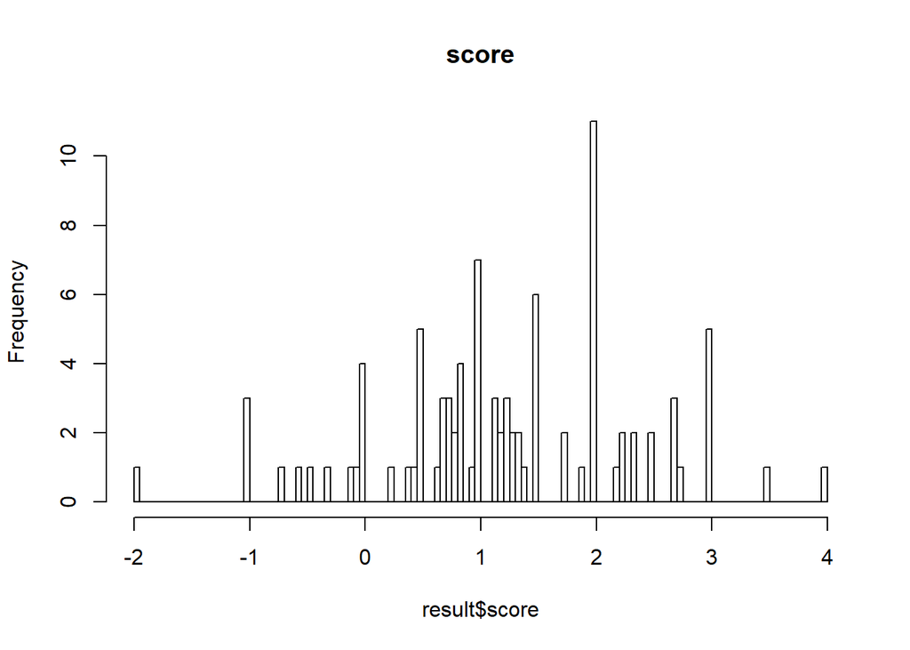

```r
score <- hist(result$score,breaks = 97,main = "score")
```

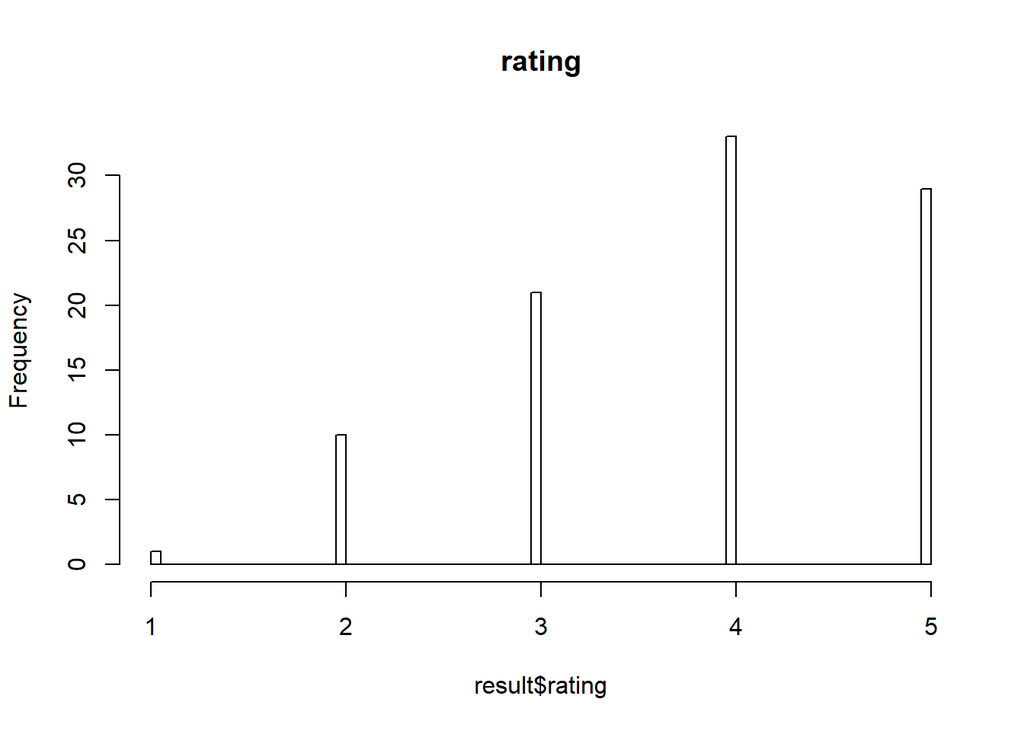

```r
rating <- hist(result$rating,breaks = 97,main = "rating")
```

```r
amazonscoremean <- mean(result$score)
amazonratingmean <- mean(result$rating)
```

```r
google1$word <- paste(google1$pros,"",google1$cons)
google1$index <- 1:nrow(google1)

tokens = google1 %>%
  unnest_tokens(word,word)
token <- tokens %>%
  inner_join(get_sentiments("afinn")) %>%
  group_by(index) %>%
  summarise(score=mean(value))
result <- token %>%
  inner_join(google1,by="index") %>%
  select(score,rating)

result <- result %>%
  mutate(rating= as.double(rating))

m <- lm(rating~score,data = result)
summary(m)
```

```
##
## Call:
## lm(formula = rating ~ score, data = result)
##
## Residuals:
##    Min     1Q Median     3Q    Max
## -2.743 -0.748  0.215  1.088  1.342
##
## Coefficients:
##             Estimate Std. Error t value Pr(>|t|)
## (Intercept)  3.91162    0.17169  22.782   <2e-16 ***
## score       -0.08443    0.08589  -0.983    0.328
## ---
## Signif. codes:  0 '***' 0.001 '**' 0.01 '*' 0.05 '.' 0.1 ' ' 1
##
## Residual standard error: 1.068 on 94 degrees of freedom
## Multiple R-squared:  0.01018,    Adjusted R-squared:  -0.0003548
## F-statistic: 0.9663 on 1 and 94 DF,  p-value: 0.3281
```

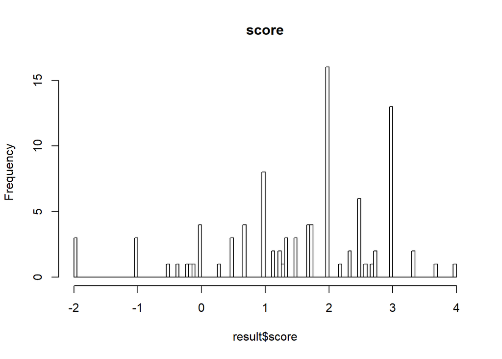

```r
score <- hist(result$score,breaks = 97,main = "score")
```

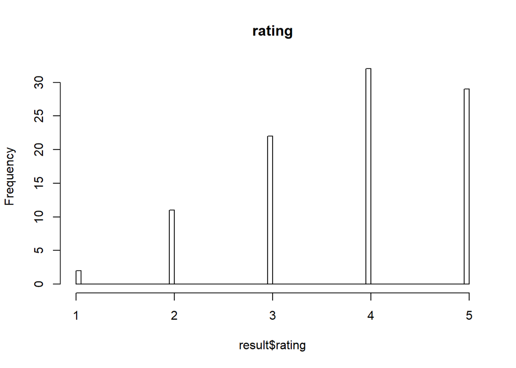

```r
rating <- hist(result$rating,breaks = 97,main = "rating")
```

```r
googlescoremean <- mean(result$score)
googleratingmean <- mean(result$rating)

amazonscoremean
```

```
## [1] 1.23594
```

```r
amazonratingmean
```

```
## [1] 3.840426
```

```r
googlescoremean
```

```
## [1] 1.544129
```

```r
googleratingmean
```

```
## [1] 3.78125
```